# ActividadIntegradora1_NallelySerna

Nallely Lizbeth Serna Rivera A00833111

Actividad Integradora 1 - Precipitaciones máximas mensuales para el diseño de obras hidráulicas

## Instrucciones

##### Varias obras de la Ingeniería Civil se ven altamente influenciadas por los factores climatológicos como la lluvia y la temperatura. En hidrología, por ejemplo, es necesario conocer el valor de la máxima precipitación probable registrada para un determinado período de retorno para realizar los cálculos y el diseño de las estructuras de conservación de agua como las presas y otras obras civiles como puentes, carreteras, y edificios. El cálculo adecuado de dimensiones para un drenaje, garantizan la correcta evacuación de volúmenes de agua asegurando la vida útil de carreteras, aeropuertos, y drenajes urbanos.

##### Se analizaran los datos históricos (1994-2023) de las precipitaciones máximas mensuales por estado para cumplir el objetivo principal de este estudio que consiste en calcular la precipitación más extrema que se logra con un periodo de retorno seleccionado. De manera individual deberás trabajar con los siguientes pasos para analizar las precipitaciones históricas del estado que selecciones y que sea diferente al resto de tu equipo.

##### Deberás investigar algunas cuestiones como los parámetros de las distribuciones.

## ANÁLISIS

Análisis estadístico descriptivo de las precipitaciones históricas máximas mensuales de un estado

A. Descarga la base de datos de precipitaciones máximas históricas mensuales de todos los estados de la república de la siguiente liga: precipitaciones mensuales Download precipitaciones mensuales. Esta base de datos se construyó con información de los resúmenes mensuales de lluvia y temperatura de CONAGUA (https://smn.conagua.gob.mx/es/Links to an external site.). Selecciona un estado que sea diferente a los del resto de tu equipo.

B. Elabora una gráfica de las precipitaciones máximas mensuales por año para tu estado. Para ello deberás calcular la precipitación mensual máxima de cada año y graficarla.

C. Analiza los datos de precipitaciones máximas mensuaels del estado seleccionado. 1. Calcula las medidas de centralización y variación de las precipitaciones máximas mensuales 2. Realiza gráficos que te sirvan para describir la distribución de las lluviar máximas mensuales: histograma y boxplot 3. Describe el comportamiento de la distribución: centralización, sesgo, variación, ....

D. ¿Qué puedes concluir observando la gráfica de los máximos mensuales anuales para tu Estado? ¿Observas alguna tendencia? ¿Puedes concluir que cada determinado número de años la cantidad de precipitación sube o baja? ¿Para qué nos sirve analizar este tipo de gráficas?

```python
df = pd.read_csv('precipitaciones_maximas_mensuales.txt', delimiter='\t')

# Filtrar los datos para el estado de Querétaro
df_queretaro = df[df['Estado'] == 'Querétaro']

# Mostrar los primeros registros del estado seleccionado
df_queretaro.head()
```

|  | Anio | Mes | Estado | Lluvia |
| --- | --- | --- | --- | --- |
| 21 | 1994 | Ene | Querétaro | 2.8 |
| 54 | 1994 | Feb | Querétaro | 0.0 |
| 87 | 1994 | Mar | Querétaro | 4.0 |
| 120 | 1994 | Abr | Querétaro | 22.8 |
| 153 | 1994 | May | Querétaro | 37.2 |

Gráfica de las precipitaciones máximas mensuales por año

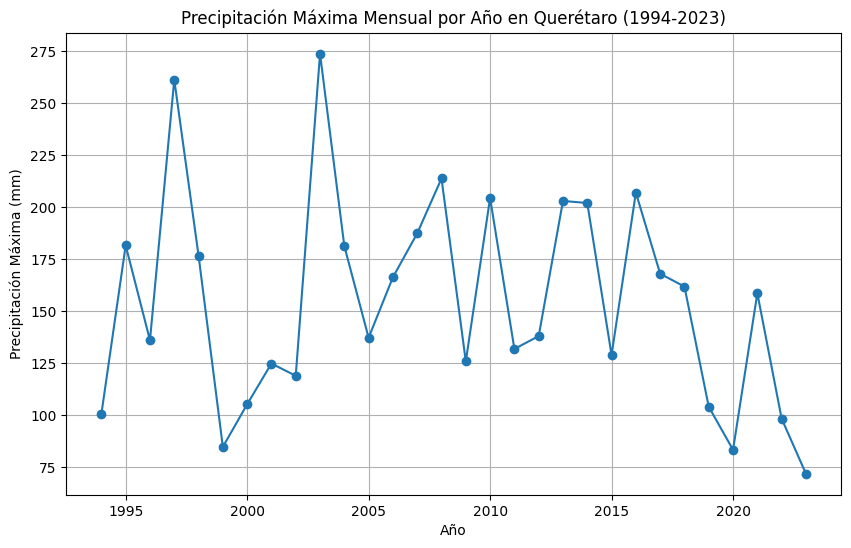

```python
# Crear un diccionario para mapear los nombres de meses en español a inglés
meses_mapa = {
    'Ene': 'Jan', 'Feb': 'Feb', 'Mar': 'Mar', 'Abr': 'Apr', 'May': 'May', 'Jun': 'Jun',
    'Jul': 'Jul', 'Ago': 'Aug', 'Sep': 'Sep', 'Oct': 'Oct', 'Nov': 'Nov', 'Dic': 'Dec'
}

# Reemplazar los nombres de meses en español con su equivalente en inglés
df_queretaro['Mes'] = df_queretaro['Mes'].replace(meses_mapa)

# Convertir las columnas 'Año' y 'Mes' a tipo datetime
df_queretaro['Fecha'] = pd.to_datetime(df_queretaro['Anio'].astype(str) + '-' + df_queretaro['Mes'], format='%Y-%b')

# Verificar la columna 'Fecha'
df_queretaro.head()


# Convertir las columnas 'Año' y 'Mes' a tipo datetime
df_queretaro['Fecha'] = pd.to_datetime(df_queretaro['Anio'].astype(str) + '-' + df_queretaro['Mes'].astype(str), format='%Y-%b')

# Calcular la precipitación máxima mensual por año
max_precip_annual = df_queretaro.groupby(df_queretaro['Anio'])['Lluvia'].max()

# Graficar las precipitaciones máximas mensuales por año
plt.figure(figsize=(10, 6))
plt.plot(max_precip_annual.index, max_precip_annual.values, marker='o')
plt.title('Precipitación Máxima Mensual por Año en Querétaro (1994-2023)')
plt.xlabel('Año')
plt.ylabel('Precipitación Máxima (mm)')
plt.grid(True)
plt.show()
```

Medidas de centralización y variación

```python
# Calcular medidas de centralización y dispersión
media = df_queretaro['Lluvia'].mean()
mediana = df_queretaro['Lluvia'].median()
desviacion = df_queretaro['Lluvia'].std()
minimo = df_queretaro['Lluvia'].min()
maximo = df_queretaro['Lluvia'].max()

print(f'Media: {media}')
print(f'Mediana: {mediana}')
print(f'Desviación estándar: {desviacion}')
print(f'Mínimo: {minimo}')
print(f'Máximo: {maximo}')
```

```
Media: 45.72
Mediana: 23.1
Desviación estándar: 52.72838310057605
Mínimo: 0.0
Máximo: 273.8
```

Histograma y Boxplot

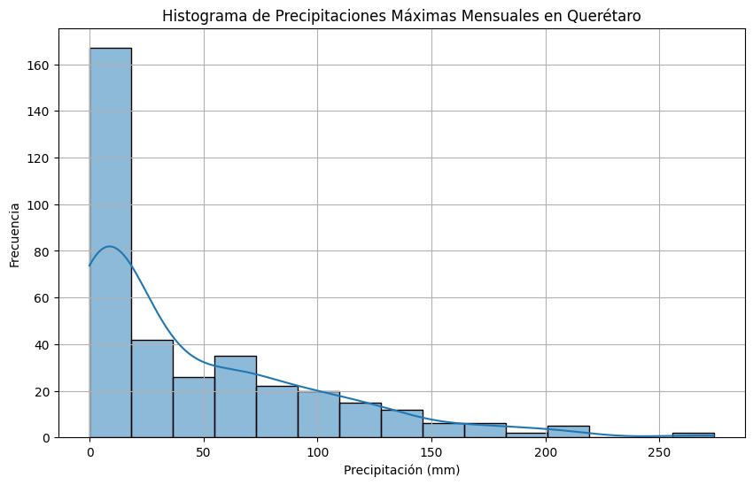

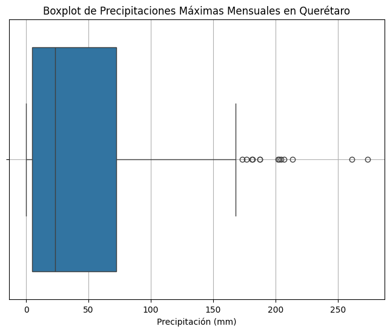

```python
# Crear el histograma
plt.figure(figsize=(10, 6))
sns.histplot(df_queretaro['Lluvia'], bins=15, kde=True)
plt.title('Histograma de Precipitaciones Máximas Mensuales en Querétaro')
plt.xlabel('Precipitación (mm)')
plt.ylabel('Frecuencia')
plt.grid(True)
plt.show()

# Crear el boxplot
plt.figure(figsize=(8, 6))
sns.boxplot(x=df_queretaro['Lluvia'])
plt.title('Boxplot de Precipitaciones Máximas Mensuales en Querétaro')
plt.xlabel('Precipitación (mm)')
plt.grid(True)
plt.show()
```

### 2.1. Análisis de frecuencias - Método gráfico

```python
import numpy as np

# Ordenar las precipitaciones máximas de mayor a menor
df_queretaro_ordenado = df_queretaro.sort_values(by='Lluvia', ascending=False).reset_index(drop=True)

# Asignar el rango (m)
df_queretaro_ordenado['Rango'] = np.arange(1, len(df_queretaro_ordenado) + 1)

# Calcular la probabilidad de excedencia con la fórmula de Weibull: P(excedencia) = m / (N + 1)
N = len(df_queretaro_ordenado)
df_queretaro_ordenado['P_excedencia'] = df_queretaro_ordenado['Rango'] / (N + 1)

# Calcular el período de retorno como el inverso de la probabilidad de excedencia
df_queretaro_ordenado['Periodo_retorno'] = 1 / df_queretaro_ordenado['P_excedencia']

# Mostrar los primeros resultados
df_queretaro_ordenado.head()
```

|  | Anio | Mes | Estado | Lluvia | Fecha | Rango | P_excedencia | Periodo_retorno |
| --- | --- | --- | --- | --- | --- | --- | --- | --- |
| 0 | 2003 | Sep | Querétaro | 273.8 | 2003-09-01 | 1 | 0.00277 | 361.000000 |
| 1 | 1997 | Jul | Querétaro | 261.3 | 1997-07-01 | 2 | 0.00554 | 180.500000 |
| 2 | 2008 | Aug | Querétaro | 213.8 | 2008-08-01 | 3 | 0.00831 | 120.333333 |
| 3 | 2016 | Aug | Querétaro | 207.0 | 2016-08-01 | 4 | 0.01108 | 90.250000 |
| 4 | 2010 | Jul | Querétaro | 204.4 | 2010-07-01 | 5 | 0.01385 | 72.200000 |

2.2. Gráficas del método gráfico

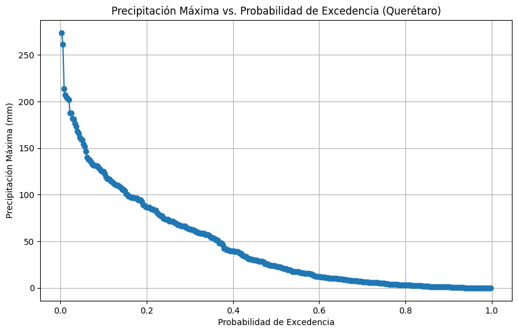

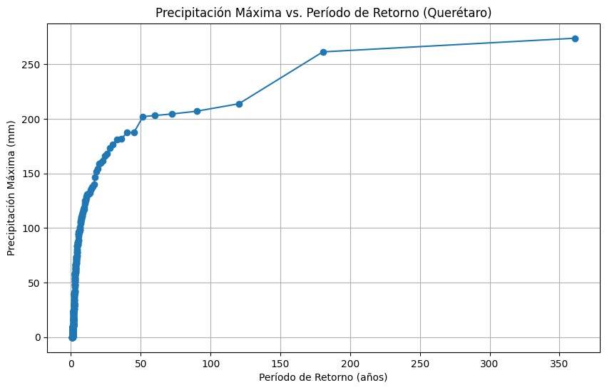

```python
# Gráfica de Precipitación Máxima vs. Probabilidad de Excedencia
plt.figure(figsize=(10, 6))
plt.plot(df_queretaro_ordenado['P_excedencia'], df_queretaro_ordenado['Lluvia'], marker='o')
plt.title('Precipitación Máxima vs. Probabilidad de Excedencia (Querétaro)')
plt.xlabel('Probabilidad de Excedencia')
plt.ylabel('Precipitación Máxima (mm)')
plt.grid(True)
plt.show()

# Gráfica de Precipitación Máxima vs. Período de Retorno
plt.figure(figsize=(10, 6))
plt.plot(df_queretaro_ordenado['Periodo_retorno'], df_queretaro_ordenado['Lluvia'], marker='o')
plt.title('Precipitación Máxima vs. Período de Retorno (Querétaro)')
plt.xlabel('Período de Retorno (años)')
plt.ylabel('Precipitación Máxima (mm)')
plt.grid(True)
plt.show()
```

### 3. Análisis de frecuencias - Método analítico

3.1. Ajuste a una distribución normal

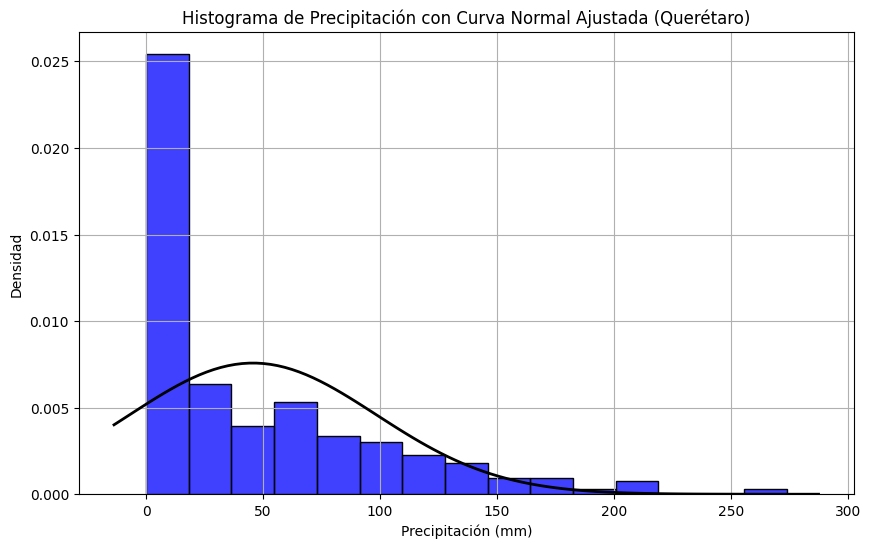

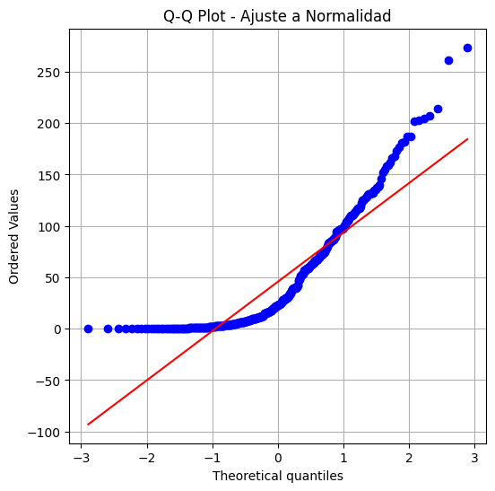

```
Shapiro-Wilk Test: Estadístico = 0.8190879821625232, p-value = 8.539258440257662e-20
Kolmogorov-Smirnov Test: Estadístico = 0.19261725350653647, p-value = 3.573026200179864e-12
```

```python
from scipy.stats import norm, shapiro, kstest, probplot

# Ajuste a la distribución normal
mu, std = norm.fit(df_queretaro['Lluvia'])

# Histograma con ajuste de la curva normal
plt.figure(figsize=(10, 6))
sns.histplot(df_queretaro['Lluvia'], bins=15, kde=False, color='blue', stat='density')
xmin, xmax = plt.xlim()
x = np.linspace(xmin, xmax, 100)
p = norm.pdf(x, mu, std)
plt.plot(x, p, 'k', linewidth=2)
plt.title('Histograma de Precipitación con Curva Normal Ajustada (Querétaro)')
plt.xlabel('Precipitación (mm)')
plt.ylabel('Densidad')
plt.grid(True)
plt.show()

# Q-Q plot para verificar ajuste a la normal
plt.figure(figsize=(6, 6))
probplot(df_queretaro['Lluvia'], dist="norm", plot=plt)
plt.title('Q-Q Plot - Ajuste a Normalidad')
plt.grid(True)
plt.show()

# Pruebas de bondad de ajuste
stat_shapiro, p_shapiro = shapiro(df_queretaro['Lluvia'])
stat_ks, p_ks = kstest(df_queretaro['Lluvia'], 'norm', args=(mu, std))

print(f'Shapiro-Wilk Test: Estadístico = {stat_shapiro}, p-value = {p_shapiro}')
print(f'Kolmogorov-Smirnov Test: Estadístico = {stat_ks}, p-value = {p_ks}')
```

3.2. Interpretación de los resultados

Histograma con curva normal: Visualmente, si los datos se ajustan a la curva normal.

Q-Q plot: Si los puntos siguen la línea diagonal, los datos son aproximadamente normales.

Pruebas de normalidad: Los p-valores nos indican si rechazamos o no la hipótesis nula de que los datos provienen de una distribución normal.

3.1. Ajuste a una distribución Log-Normal

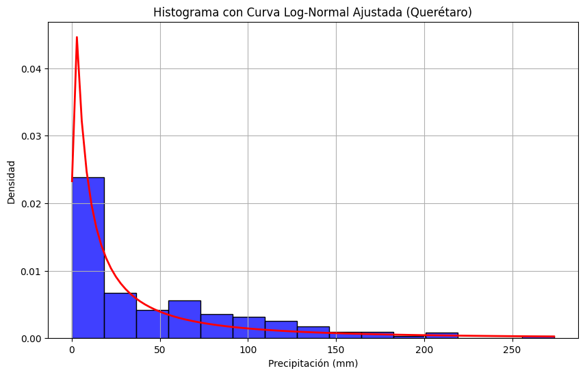

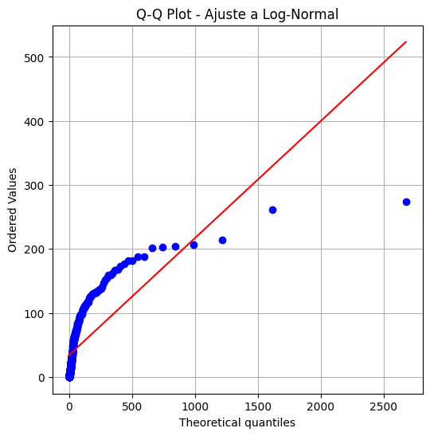

```
Kolmogorov-Smirnov Test para Log-normal: Estadístico = 0.10453549999204481, p-value = 0.001044039358457743
```

```python
from scipy.stats import lognorm

# Eliminar los valores de precipitación que sean 0, ya que no son válidos para la distribución log-normal
df_queretaro_lognorm = df_queretaro[df_queretaro['Lluvia'] > 0]

# Ajuste a la distribución log-normal
shape, loc, scale = lognorm.fit(df_queretaro_lognorm['Lluvia'], floc=0)

# Histograma con ajuste de la curva log-normal
plt.figure(figsize=(10, 6))
sns.histplot(df_queretaro_lognorm['Lluvia'], bins=15, kde=False, color='blue', stat='density')
x = np.linspace(df_queretaro_lognorm['Lluvia'].min(), df_queretaro_lognorm['Lluvia'].max(), 100)
pdf_log = lognorm.pdf(x, shape, loc, scale)
plt.plot(x, pdf_log, 'r', linewidth=2)
plt.title('Histograma con Curva Log-Normal Ajustada (Querétaro)')
plt.xlabel('Precipitación (mm)')
plt.ylabel('Densidad')
plt.grid(True)
plt.show()

# Q-Q plot para la distribución log-normal
plt.figure(figsize=(6, 6))
probplot(df_queretaro_lognorm['Lluvia'], dist="lognorm", sparams=(shape, loc, scale), plot=plt)
plt.title('Q-Q Plot - Ajuste a Log-Normal')
plt.grid(True)
plt.show()


# Prueba KS para Log-normal
stat_ks_lognorm, p_ks_lognorm = kstest(df_queretaro_lognorm['Lluvia'], 'lognorm', args=(shape, loc, scale))
print(f'Kolmogorov-Smirnov Test para Log-normal: Estadístico = {stat_ks_lognorm}, p-value = {p_ks_lognorm}')
```

3.2. Ajuste a una distribución Curva Exponencial Ajustada

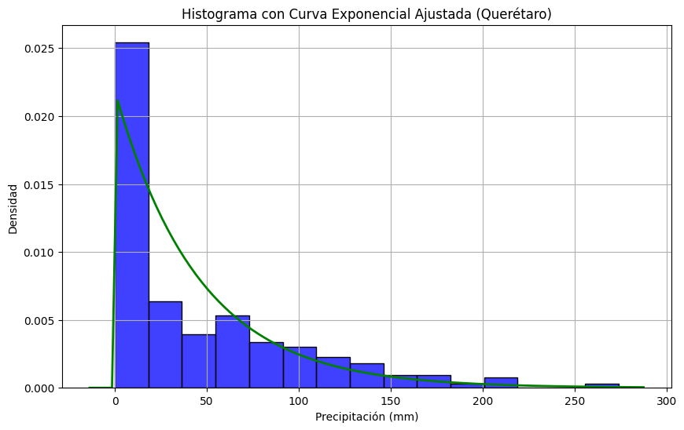

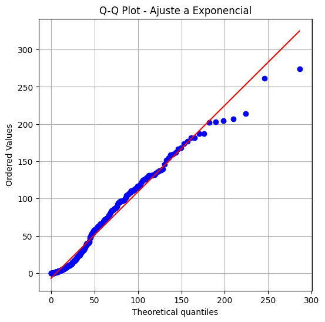

```
Kolmogorov-Smirnov Test para Exponencial: Estadístico = 0.1746688401745609, p-value = 4.469315814124027e-10
```

```python
from scipy.stats import expon

# Ajuste a la distribución exponencial
loc_exp, scale_exp = expon.fit(df_queretaro['Lluvia'])

# Histograma con ajuste de la curva exponencial
plt.figure(figsize=(10, 6))
sns.histplot(df_queretaro['Lluvia'], bins=15, kde=False, color='blue', stat='density')
pdf_exp = expon.pdf(x, loc_exp, scale_exp)
plt.plot(x, pdf_exp, 'g', linewidth=2)
plt.title('Histograma con Curva Exponencial Ajustada (Querétaro)')
plt.xlabel('Precipitación (mm)')
plt.ylabel('Densidad')
plt.grid(True)
plt.show()

# Q-Q plot para la distribución exponencial
plt.figure(figsize=(6, 6))
probplot(df_queretaro['Lluvia'], dist="expon", sparams=(loc_exp, scale_exp), plot=plt)
plt.title('Q-Q Plot - Ajuste a Exponencial')
plt.grid(True)
plt.show()

# Prueba KS para Exponencial
stat_ks_expon, p_ks_expon = kstest(df_queretaro['Lluvia'], 'expon', args=(loc_exp, scale_exp))

print(f'Kolmogorov-Smirnov Test para Exponencial: Estadístico = {stat_ks_expon}, p-value = {p_ks_expon}')
```

3.3. Ajuste a una distribución Curva Gamma Ajustada

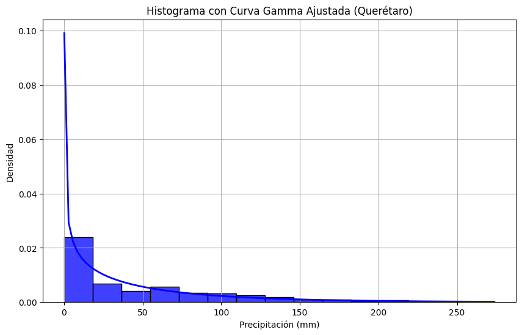

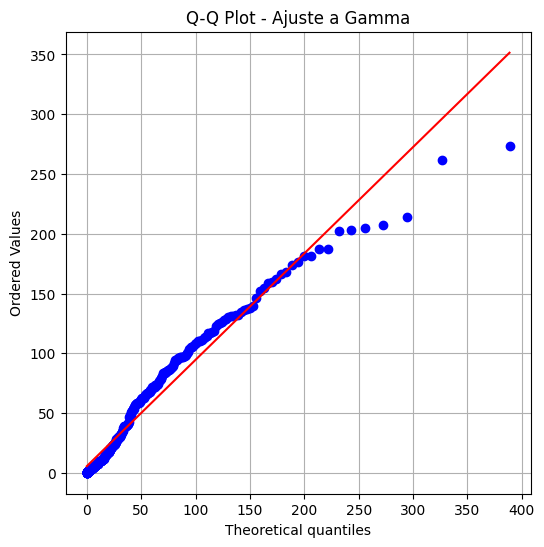

```
Kolmogorov-Smirnov Test para Gamma: Estadístico = 0.07136705654157549, p-value = 0.05842654966854344
```

```python
from scipy.stats import gamma

# Eliminar los valores de precipitación que sean 0, ya que no son válidos para la distribución Gamma
df_queretaro_gamma = df_queretaro[df_queretaro['Lluvia'] > 0]

# Ajuste a la distribución gamma
shape_gamma, loc_gamma, scale_gamma = gamma.fit(df_queretaro_gamma['Lluvia'], floc=0)

# Histograma con ajuste de la curva gamma
plt.figure(figsize=(10, 6))
sns.histplot(df_queretaro_gamma['Lluvia'], bins=15, kde=False, color='blue', stat='density')
x = np.linspace(df_queretaro_gamma['Lluvia'].min(), df_queretaro_gamma['Lluvia'].max(), 100)
pdf_gamma = gamma.pdf(x, shape_gamma, loc_gamma, scale_gamma)
plt.plot(x, pdf_gamma, 'b', linewidth=2)
plt.title('Histograma con Curva Gamma Ajustada (Querétaro)')
plt.xlabel('Precipitación (mm)')
plt.ylabel('Densidad')
plt.grid(True)
plt.show()

# Q-Q plot para la distribución gamma
plt.figure(figsize=(6, 6))
probplot(df_queretaro_gamma['Lluvia'], dist="gamma", sparams=(shape_gamma, loc_gamma, scale_gamma), plot=plt)
plt.title('Q-Q Plot - Ajuste a Gamma')
plt.grid(True)
plt.show()

# Prueba KS para Gamma
stat_ks_gamma, p_ks_gamma = kstest(df_queretaro_gamma['Lluvia'], 'gamma', args=(shape_gamma, loc_gamma, scale_gamma))
print(f'Kolmogorov-Smirnov Test para Gamma: Estadístico = {stat_ks_gamma}, p-value = {p_ks_gamma}')
```

3.4. Ajuste a una distribución Curva Weibull Ajustada

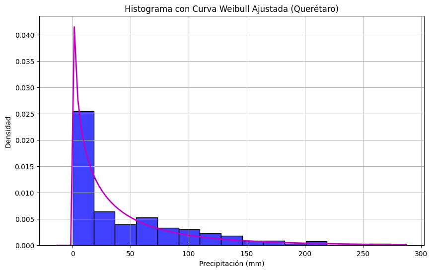

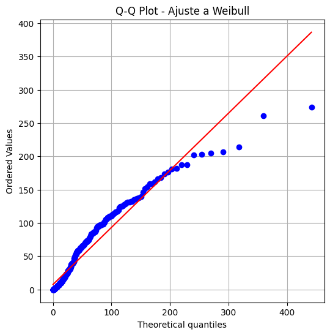

```
Kolmogorov-Smirnov Test para Weibull: Estadístico = 0.08911035678570733, p-value = 0.006156489499313511
```

```python
from scipy.stats import weibull_min

# Ajuste a la distribución Weibull
shape_weibull, loc_weibull, scale_weibull = weibull_min.fit(df_queretaro['Lluvia'], floc=0)

# Histograma con ajuste de la curva Weibull
plt.figure(figsize=(10, 6))
sns.histplot(df_queretaro['Lluvia'], bins=15, kde=False, color='blue', stat='density')
pdf_weibull = weibull_min.pdf(x, shape_weibull, loc_weibull, scale_weibull)
plt.plot(x, pdf_weibull, 'm', linewidth=2)
plt.title('Histograma con Curva Weibull Ajustada (Querétaro)')
plt.xlabel('Precipitación (mm)')
plt.ylabel('Densidad')
plt.grid(True)
plt.show()

# Q-Q plot para la distribución Weibull
plt.figure(figsize=(6, 6))
probplot(df_queretaro['Lluvia'], dist="weibull_min", sparams=(shape_weibull, loc_weibull, scale_weibull), plot=plt)
plt.title('Q-Q Plot - Ajuste a Weibull')
plt.grid(True)
plt.show()

# Prueba KS para Weibull
stat_ks_weibull, p_ks_weibull = kstest(df_queretaro['Lluvia'], 'weibull_min', args=(shape_weibull, loc_weibull, scale_weibull))

print(f'Kolmogorov-Smirnov Test para Weibull: Estadístico = {stat_ks_weibull}, p-value = {p_ks_weibull}')
```

3.5. Ajuste a una distribución Curva Gumbel Ajustada

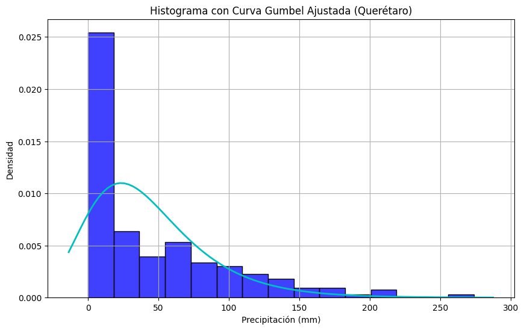

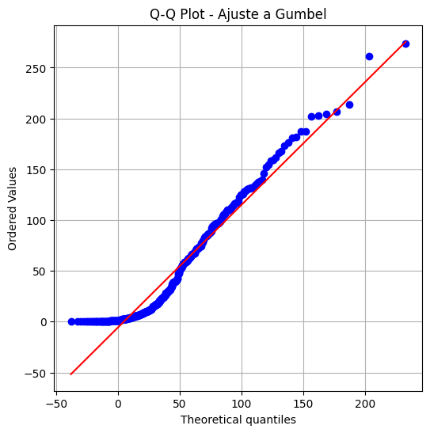

```
Kolmogorov-Smirnov Test para Gumbel: Estadístico = 0.15952535540992635, p-value = 1.8044914003238574e-08
```

```python
from scipy.stats import gumbel_r

# Ajuste a la distribución Gumbel
loc_gumbel, scale_gumbel = gumbel_r.fit(df_queretaro['Lluvia'])

# Histograma con ajuste de la curva Gumbel
plt.figure(figsize=(10, 6))
sns.histplot(df_queretaro['Lluvia'], bins=15, kde=False, color='blue', stat='density')
pdf_gumbel = gumbel_r.pdf(x, loc_gumbel, scale_gumbel)
plt.plot(x, pdf_gumbel, 'c', linewidth=2)
plt.title('Histograma con Curva Gumbel Ajustada (Querétaro)')
plt.xlabel('Precipitación (mm)')
plt.ylabel('Densidad')
plt.grid(True)
plt.show()

# Q-Q plot para la distribución Gumbel
plt.figure(figsize=(6, 6))
probplot(df_queretaro['Lluvia'], dist="gumbel_r", sparams=(loc_gumbel, scale_gumbel), plot=plt)
plt.title('Q-Q Plot - Ajuste a Gumbel')
plt.grid(True)
plt.show()

# Prueba KS para Gumbel
stat_ks_gumbel, p_ks_gumbel = kstest(df_queretaro['Lluvia'], 'gumbel_r', args=(loc_gumbel, scale_gumbel))

print(f'Kolmogorov-Smirnov Test para Gumbel: Estadístico = {stat_ks_gumbel}, p-value = {p_ks_gumbel}')
```

Comparación de Ajustes a Diferentes Distribuciones

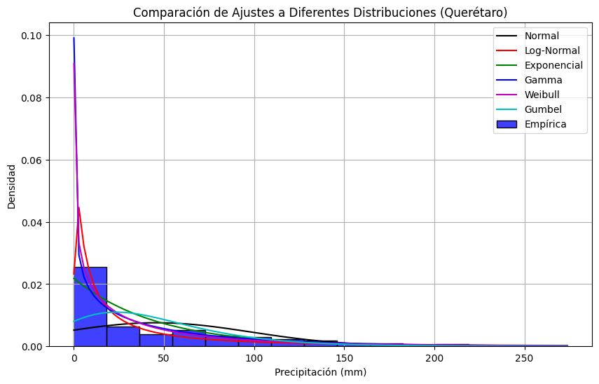

```python
# Gráfico comparativo de todas las distribuciones
plt.figure(figsize=(10, 6))
sns.histplot(df_queretaro['Lluvia'], bins=15, kde=False, color='blue', stat='density', label='Empírica')

# Superponer las densidades teóricas
plt.plot(x, norm.pdf(x, mu, std), 'k-', label='Normal')
plt.plot(x, lognorm.pdf(x, shape, loc, scale), 'r-', label='Log-Normal')
plt.plot(x, expon.pdf(x, loc_exp, scale_exp), 'g-', label='Exponencial')
plt.plot(x, gamma.pdf(x, shape_gamma, loc_gamma, scale_gamma), 'b-', label='Gamma')
plt.plot(x, weibull_min.pdf(x, shape_weibull, loc_weibull, scale_weibull), 'm-', label='Weibull')
plt.plot(x, gumbel_r.pdf(x, loc_gumbel, scale_gumbel), 'c-', label='Gumbel')

plt.title('Comparación de Ajustes a Diferentes Distribuciones (Querétaro)')
plt.xlabel('Precipitación (mm)')
plt.ylabel('Densidad')
plt.legend()
plt.grid(True)
plt.show()
```

### 4. Precipitación de diseño de obras hidráulicas

4.1. Gráfico comparativo de la probabilidad de excedencia teórica vs. empírica

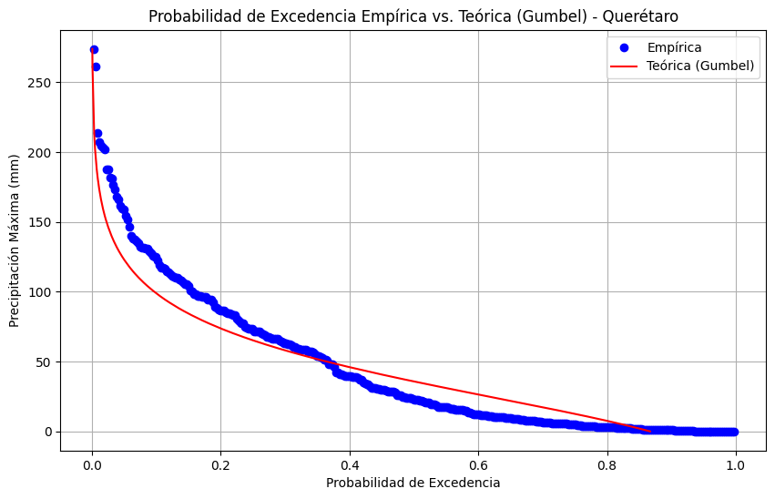

```python
# Probabilidad de excedencia empírica ya calculada anteriormente
P_excedencia_empirica = df_queretaro_ordenado['P_excedencia']

# Calcular la probabilidad de excedencia teórica para la distribución Gumbel
P_excedencia_teorica_gumbel = gumbel_r.sf(df_queretaro_ordenado['Lluvia'], loc=loc_gumbel, scale=scale_gumbel)

# Gráfico comparativo de la probabilidad de excedencia empírica vs. teórica (Gumbel)
plt.figure(figsize=(10, 6))
plt.plot(P_excedencia_empirica, df_queretaro_ordenado['Lluvia'], 'bo', label='Empírica')
plt.plot(P_excedencia_teorica_gumbel, df_queretaro_ordenado['Lluvia'], 'r-', label='Teórica (Gumbel)')
plt.title('Probabilidad de Excedencia Empírica vs. Teórica (Gumbel) - Querétaro')
plt.xlabel('Probabilidad de Excedencia')
plt.ylabel('Precipitación Máxima (mm)')
plt.legend()
plt.grid(True)
plt.show()
```

4.2. Cálculo de la precipitación máxima para un período de retorno

```python
# Definir el período de retorno
periodo_retorno = 100  # años

# Calcular la probabilidad de excedencia para este período de retorno
P_excedencia_retorno = 1 / periodo_retorno

# Calcular la precipitación máxima mensual para este período de retorno usando la distribución Gumbel
precip_max_retorno = gumbel_r.isf(P_excedencia_retorno, loc=loc_gumbel, scale=scale_gumbel)

print(f'Precipitación máxima mensual para un período de retorno de {periodo_retorno} años: {precip_max_retorno:.2f} mm')
```

```
Precipitación máxima mensual para un período de retorno de 100 años: 177.48 mm
```

4.4. Explorar otros períodos de retorno

```python
# Calcular la precipitación para otros períodos de retorno
periodos = [50, 100, 200, 500]
precipitaciones_retorno = [gumbel_r.isf(1 / p, loc=loc_gumbel, scale=scale_gumbel) for p in periodos]

# Mostrar los resultados
for p, precip in zip(periodos, precipitaciones_retorno):
    print(f'Precipitación máxima para un período de retorno de {p} años: {precip:.2f} mm')
```

```
Precipitación máxima para un período de retorno de 50 años: 154.11 mm
Precipitación máxima para un período de retorno de 100 años: 177.48 mm
Precipitación máxima para un período de retorno de 200 años: 200.77 mm
Precipitación máxima para un período de retorno de 500 años: 231.50 mm
```